# Homework 10

2024-02-22

## Instructions

Answer the following questions and complete the exercises in RMarkdown. Please embed all of your code and push your final work to your repository. Your final lab report should be organized, clean, and run free from errors. Remember, you must remove the `#` for the included code chunks to run. Be sure to add your name to the author header above. For any included plots, make sure they are clearly labeled. You are free to use any plot type that you feel best communicates the results of your analysis.

Make sure to use the formatting conventions of RMarkdown to make your report neat and clean!

## Load the libraries

```r
library(tidyverse)
library(janitor)
library(naniar)
```

## Desert Ecology

For this assignment, we are going to use a modified data set on [desert ecology](http://esapubs.org/archive/ecol/E090/118/). The data are from: S. K. Morgan Ernest, Thomas J. Valone, and James H. Brown. 2009. Long-term monitoring and experimental manipulation of a Chihuahuan Desert ecosystem near Portal, Arizona, USA. Ecology 90:1708.

```r
deserts <- read_csv("../lab11/data/surveys_complete.csv") %>% clean_names()
```

1. Use the function(s) of your choice to get an idea of its structure, including how NA’s are treated. Are the data tidy?

```r
glimpse(deserts)
```

```
## Rows: 34,786
## Columns: 13
## $ record_id       <dbl> 1, 2, 3, 4, 5, 6, 7, 8, 9, 10, 11, 12, 13, 14, 15, 16,…
## $ month           <dbl> 7, 7, 7, 7, 7, 7, 7, 7, 7, 7, 7, 7, 7, 7, 7, 7, 7, 7, …
## $ day             <dbl> 16, 16, 16, 16, 16, 16, 16, 16, 16, 16, 16, 16, 16, 16…
## $ year            <dbl> 1977, 1977, 1977, 1977, 1977, 1977, 1977, 1977, 1977, …
## $ plot_id         <dbl> 2, 3, 2, 7, 3, 1, 2, 1, 1, 6, 5, 7, 3, 8, 6, 4, 3, 2, …
## $ species_id      <chr> "NL", "NL", "DM", "DM", "DM", "PF", "PE", "DM", "DM", …
## $ sex             <chr> "M", "M", "F", "M", "M", "M", "F", "M", "F", "F", "F",…
## $ hindfoot_length <dbl> 32, 33, 37, 36, 35, 14, NA, 37, 34, 20, 53, 38, 35, NA…
## $ weight          <dbl> NA, NA, NA, NA, NA, NA, NA, NA, NA, NA, NA, NA, NA, NA…
## $ genus           <chr> "Neotoma", "Neotoma", "Dipodomys", "Dipodomys", "Dipod…
## $ species         <chr> "albigula", "albigula", "merriami", "merriami", "merri…
## $ taxa            <chr> "Rodent", "Rodent", "Rodent", "Rodent", "Rodent", "Rod…
## $ plot_type       <chr> "Control", "Long-term Krat Exclosure", "Control", "Rod…
```

2. How many genera and species are represented in the data? What are the total number of observations? Which species is most/ least frequently sampled in the study?

```r
deserts %>%
  count(species)
```

```
## # A tibble: 40 × 2
##    species             n
##    <chr>           <int>
##  1 albigula         1252
##  2 audubonii          75
##  3 baileyi          2891
##  4 bilineata         303
##  5 brunneicapillus    50
##  6 chlorurus          39
##  7 clarki              1
##  8 eremicus         1299
##  9 flavus           1597
## 10 fulvescens         75
## # ℹ 30 more rows
```

```r
deserts %>%
  count(genus, sort=T)
```

```
## # A tibble: 26 × 2
##    genus                n
##    <chr>            <int>
##  1 Dipodomys        16167
##  2 Chaetodipus       6029
##  3 Onychomys         3267
##  4 Reithrodontomys   2694
##  5 Peromyscus        2234
##  6 Perognathus       1629
##  7 Neotoma           1252
##  8 Ammospermophilus   437
##  9 Amphispiza         303
## 10 Spermophilus       249
## # ℹ 16 more rows
```

```r
deserts %>%
  count(record_id)
```

```
## # A tibble: 34,786 × 2
##    record_id     n
##        <dbl> <int>
##  1         1     1
##  2         2     1
##  3         3     1
##  4         4     1
##  5         5     1
##  6         6     1
##  7         7     1
##  8         8     1
##  9         9     1
## 10        10     1
## # ℹ 34,776 more rows
```

3. What is the proportion of taxa included in this study? Show a table and plot that reflects this count.

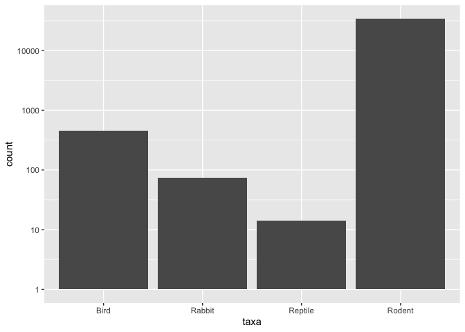

```r
deserts %>%
  ggplot(aes(taxa)) + geom_bar() + scale_y_log10()
```

4. For the taxa included in the study, use the fill option to show the proportion of individuals sampled by `plot_type.`

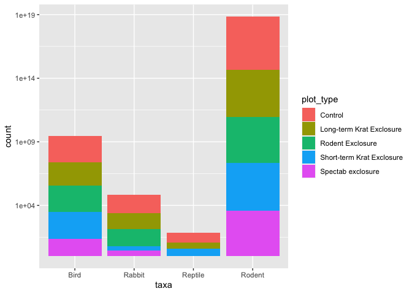

```r
deserts %>%
  ggplot(aes(taxa, fill = plot_type)) + geom_bar() + scale_y_log10()
```

5. What is the range of weight for each species included in the study? Remove any observations of weight that are NA so they do not show up in the plot.

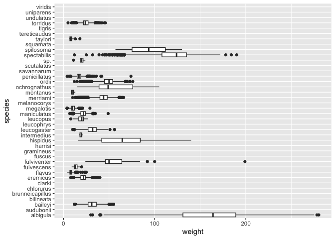

```r
deserts %>%
  ggplot(aes(species, weight)) + geom_boxplot(na.rm = T) + coord_flip()
```

6. Add another layer to your answer from #5 using `geom_point` to get an idea of how many measurements were taken for each species.

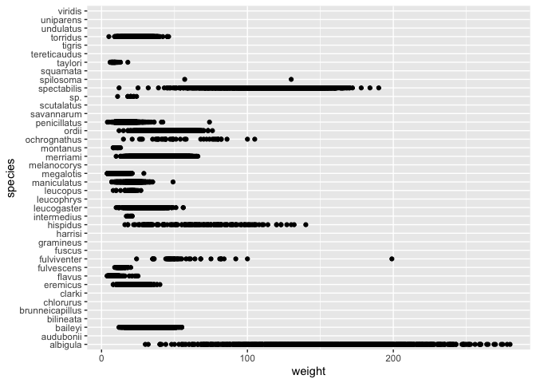

```r
deserts %>%
  ggplot(aes(species, weight)) + geom_point(na.rm = T) + coord_flip()
```

7. [Dipodomys merriami](https://en.wikipedia.org/wiki/Merriam's_kangaroo_rat) is the most frequently sampled animal in the study. How have the number of observations of this species changed over the years included in the study?

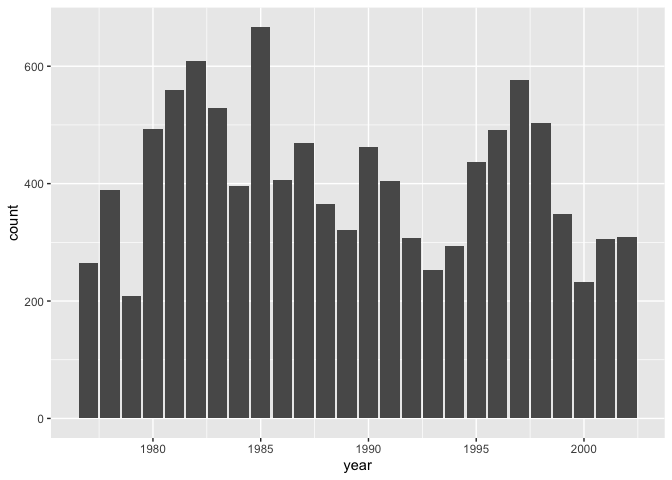

```r
deserts %>%
  filter(genus == "Dipodomys" & species == "merriami") %>%
  ggplot(aes(year)) + geom_bar()
```

8. What is the relationship between `weight` and `hindfoot` length? Consider whether or not over plotting is an issue.

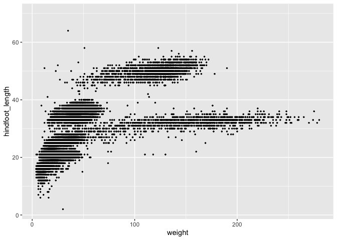

```r
deserts %>%
  ggplot(aes(weight, hindfoot_length)) + geom_point(na.rm = T, size= .5)
```

9. Which two species have, on average, the highest weight? Once you have identified them, make a new column that is a ratio of `weight` to `hindfoot_length`. Make a plot that shows the range of this new ratio and fill by sex.

```r
deserts %>%
  group_by(species_id) %>%
  summarise(meanweight = mean(weight, na.rm = T)) %>%
  arrange(desc(meanweight))
```

```
## # A tibble: 48 × 2
##    species_id meanweight
##    <chr>           <dbl>
##  1 NL              159.
##  2 DS              120.
##  3 SS               93.5
##  4 SH               73.1
##  5 SF               58.9
##  6 SO               55.4
##  7 DO               48.9
##  8 DM               43.2
##  9 PB               31.7
## 10 OL               31.6
## # ℹ 38 more rows
```

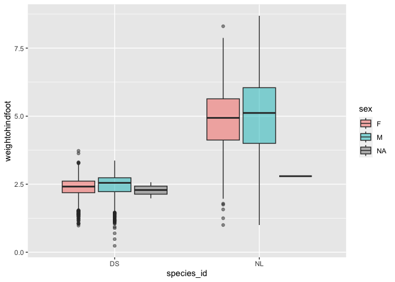

```r
deserts %>%
  mutate(weightohindfoot = weight/hindfoot_length) %>%
  filter(species_id == "NL" | species_id == "DS") %>%
  ggplot(aes(species_id, weightohindfoot, fill=sex)) + geom_boxplot(na.rm = T, alpha = .5)
```

10. Make one plot of your choice! Make sure to include at least two of the aesthetics options you have learned.

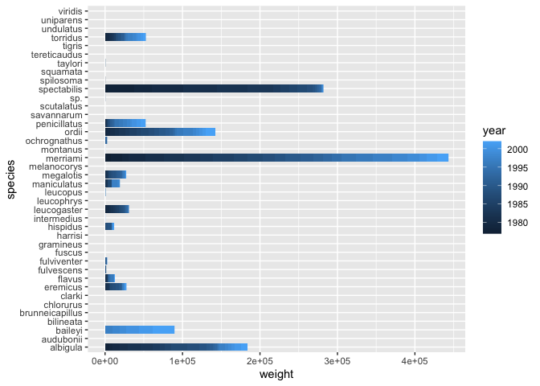

```r
deserts %>%
  group_by(year) %>%
  ggplot(aes(species, weight, fill = year)) + geom_col(na.rm = T) + coord_flip()
```

## Push your final code to GitHub!

Please be sure that you check the `keep md` file in the knit preferences.